# 2018_0709_tetraploid_kmers

Kirk Amundson

```r
library(tidyverse)
library(ggplot2)
```

```r
sup.counts <- read.csv("histo_SRR2069942_counts.txt", header = F, sep = " ")
head(sup.counts)
```

|  | V1 | V2 |
| --- | --- | --- |
| 1 | 1 | 480259283 |
| 2 | 2 | 158203430 |
| 3 | 3 | 150648760 |
| 4 | 4 | 126253835 |
| 5 | 5 | 100643349 |
| 6 | 6 | 80827508 |

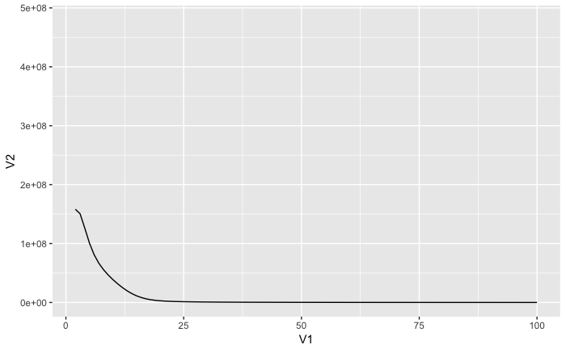

```r
ggplot(sup.counts, aes(x = V1, y = V2)) +
  # geom_histogram(binwidth = 1, stat = "identity") +
  scale_x_continuous(limits = c(2, 100)) +
  geom_line()
```

```r
rb.counts <- read.csv("histo_SRR5349587_counts.txt", header = F, sep = " ")
head(rb.counts)
```

|  | V1 | V2 |
| --- | --- | --- |
| 1 | 1 | 706306718 |
| 2 | 2 | 149542515 |
| 3 | 3 | 141549991 |
| 4 | 4 | 125356010 |
| 5 | 5 | 103774902 |
| 6 | 6 | 84531633 |

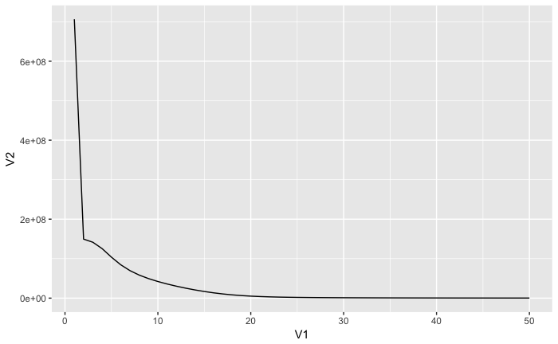

```r
ggplot(rb.counts, aes(x = V1, y = V2)) +
  # geom_histogram(binwidth = 1, stat = "identity") +
  geom_line() +
  scale_x_continuous(limits = c(1, 50))
```

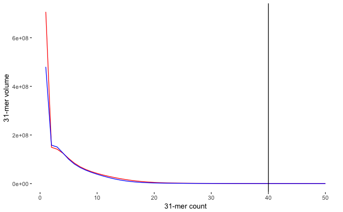

```r
ggplot() +
  geom_line(data = rb.counts, aes(x = V1, y = V2), color = "red") +
  geom_line(data = sup.counts, aes(x = V1, y = V2), color = "blue") +
  geom_vline(xintercept = 40, color = "black") +
  scale_x_continuous(limits = c(1, 50)) +
  labs(x = "31-mer count", y = "31-mer volume") +
  theme(panel.background = element_rect(fill = "white"))
```

> Can’t really fit a linear regression to this. Could still detect repetitive fraction by, e.g., cutting at 40.

I pooled all Superior reads and redid the k-mer count and histogram generation with Jellyfish. Plot below

```r
sup.all.counts <- read.csv("superior_all_counts.txt", header = F, sep = " ")
head(sup.all.counts)
```

|  | V1 | V2 |
| --- | --- | --- |
| 1 | 1 | 742710850 |
| 2 | 2 | 402428465 |
| 3 | 3 | 20191446 |
| 4 | 4 | 18551335 |
| 5 | 5 | 19208711 |
| 6 | 6 | 24771581 |

```r
tail(sup.all.counts)
```

|  | V1 | V2 |
| --- | --- | --- |
| 9996 | 9996 | 12 |
| 9997 | 9997 | 21 |
| 9998 | 9998 | 21 |
| 9999 | 9999 | 14 |
| 10000 | 10000 | 14 |
| 10001 | 10001 | 90664 |

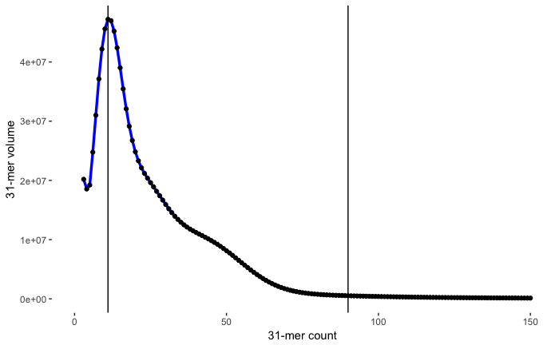

```r
ggplot(filter(sup.all.counts, V1 >= 3), aes(x = V1, y = V2)) +
  geom_line(color = "blue", size = 1.2) +
  geom_point() +
  geom_vline(xintercept = 90) +
  geom_vline(xintercept = 11) +
  scale_x_continuous(limits = c(0, 150)) +
  labs(x = "31-mer count", y = "31-mer volume") +
  theme(panel.background = element_rect(fill = "white"))
```

> Extrapolate genome size from 31mer distribution:

```r
# calculate total number of 31-mers in the non-error distribution, defined here as k-mers with volume 4 and higher
sum(as.numeric(sup.all.counts[4:10000,1] * sup.all.counts[4:10000,2]))
```

```
[1] 36664614403
```

> There are about 36.6G k-mers in this region. Next, we want to know the peak position. From the graph, it is between 11 and 12

```r
sup.all.counts[5:15,]
```

[output not shown]

> Here, the peak is at 11. Then, the genome size is estimated as:

```r
sum(as.numeric(sup.all.counts[4:10000,1] * sup.all.counts[4:10000,2])) / 11
3333146764 / 1e9
```

> This reads as ~3.33Gb, less than 4 * 844e6, implying that much of the 4 subgenomes are distinct at 31-mer resolution. Alternatively, Superior may have a slightly contracted genome relative to DM1-3. If I wanted to determine this for sure, I would also have to count 31-mers in DM1-3.

```r
(sum(as.numeric(sup.all.counts[4:10000,1] * sup.all.counts[4:10000,2])) / 11) / (4*844e6)
```

> If we assume that the nonrepetitive region is between 4 and 90, the size of the nonrepetitive region can be rougly calculated:

```r
sum(as.numeric(sup.all.counts[4:90,1] * sup.all.counts[4:90,2])) / 11
2466831540 / 1e9
2466831540 / 3333146764
```

> This is 2.46Gb or about 74% of the genome. However, you should really question whether this assumption is valid, as homozygous regions will be conflated with low copy repeats. For high-copy repeat analysis, I will be analyzing the most repetitive 26% (or less) fraction of the genome.

What copy number defines the top 20% most repetitive 31-mers of the genome?

```r
# try 180 for no good reason at all
sum(as.numeric(sup.all.counts[4:180,1] * sup.all.counts[4:180,2])) / 11
2674351977 / 3333146764
```

> I almost nailed it! Top 20% begins at copy number 175

```r
(sum(as.numeric(sup.all.counts[4:175,1] * sup.all.counts[4:175,2])) / 11) / 3333146764
```

[output not shown]

> Determining the abundance of Russet Burbank high copy k-mers in superior will be relatively easy. The Superior to Russet Burbank comparison will be more challenging, as the inferred single copy peak cannot be distinguished from erroneous k-mers.

```r
st24.counts.sup <- read.csv("St24_31mer_counts_Sup.txt",header=F, sep = " ")
head(st24.counts.sup)
```

|  | V1 | V2 |
| --- | --- | --- |
| 1 | GGTTTGATGGAGTGTTCACAAGGATAGAGGA | 1 |
| 2 | AGCAACCCTCGTTTCTAAACAAGGTTCAATA | 16 |
| 3 | CATAGAGCAACCTAAGGTTATATTAAACCCA | 5 |
| 4 | CATTAGCCAAATCGGGTCACTTTTGGGCTCA | 0 |
| 5 | CCTTATGGCTCGGCAATGCCCCCAATACTCG | 0 |
| 6 | TCCTCTTGTTGTGTCTTTCTATTTATCCAGA | 10 |

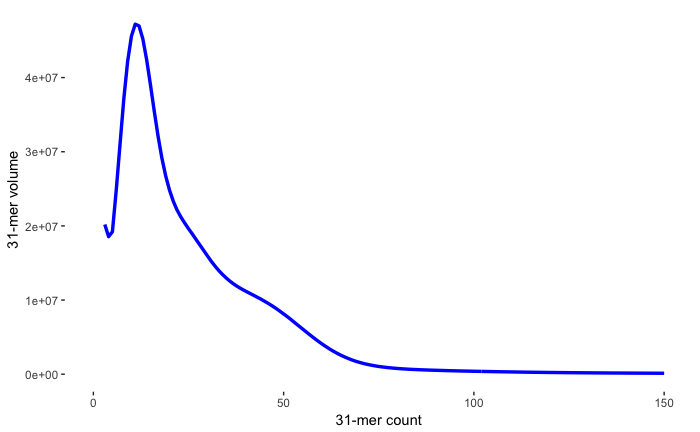

```r
ggplot(filter(sup.all.counts, V1 >= 3), aes(x = V1, y = V2)) +
  geom_line(color = "blue", size = 1.2) +
  # geom_vline(xintercept=c(unique(st24.counts.sup$V2))) +
  scale_x_continuous(limits = c(0, 150)) +
  labs(x = "31-mer count", y = "31-mer volume") +
  theme(panel.background = element_rect(fill = "white"))
```

```r
st24.counts.sup.indexed <- read.csv("St24_31mer_index_counts_sup.txt",header=F,sep=' ') %>%
  mutate(V5 = V2 / 59.27)
head(st24.counts.sup.indexed)
```

|  | V1 | V2 | V3 | V4 | V5 |
| --- | --- | --- | --- | --- | --- |
| 1 | AGCGAGGAGGAGCAACTGAAGGTGTGCTTCA | 2 | 0 | NA | 0.03374388 |
| 2 | AAGCGAGGAGGAGCAACTGAAGGTGTGCTTC | 2 | 1 | NA | 0.03374388 |
| 3 | AAGCACACCTTCAGTTGCTCCTCCTCGCTTA | 2 | 2 | NA | 0.03374388 |
| 4 | AGCACACCTTCAGTTGCTCCTCCTCGCTTAG | 2 | 3 | NA | 0.03374388 |
| 5 | ACTAAGCGAGGAGGAGCAACTGAAGGTGTGC | 2 | 4 | NA | 0.03374388 |
| 6 | AACTAAGCGAGGAGGAGCAACTGAAGGTGTG | 2 | 5 | NA | 0.03374388 |

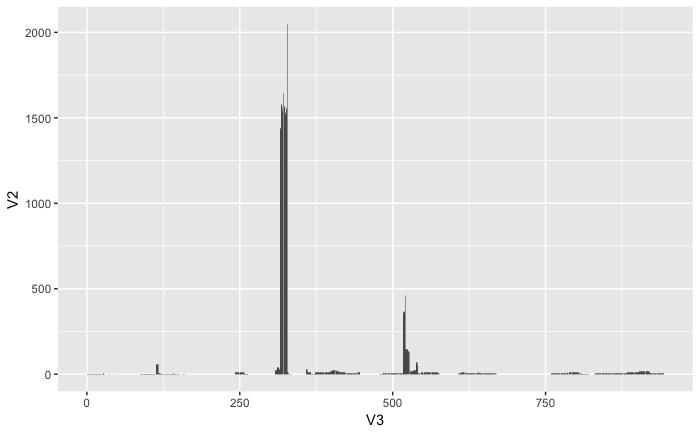

```r
# raw counts, will eventually want to normalize per monoploid genome to even out the discrepancy in sequencing depth
ggplot(st24.counts.sup.indexed, aes(x = V3, y = V2)) +
  geom_bar(stat="identity")
```

```r
st24.counts.rb.indexed <- read.csv("St24_31mer_index_counts_rb.txt", header = F, sep = " ") %>%
  mutate(V4 = -1*V2) %>%
  mutate(V5 = V2 / 16.2) %>%
  mutate(V6 = -1*V5)
View(st24.counts.rb.indexed)
```

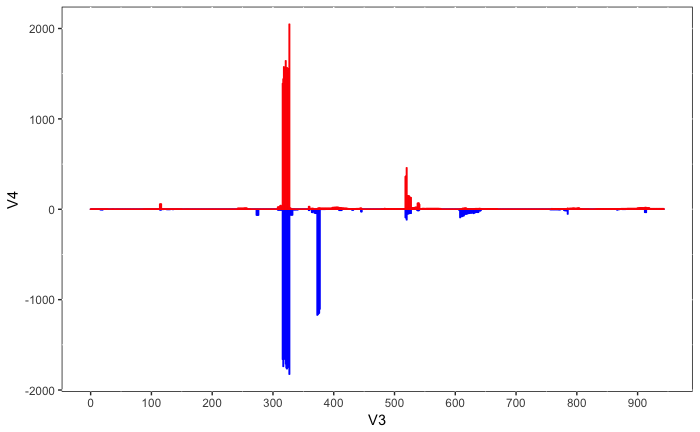

```r
ggplot(st24.counts.rb.indexed, aes(x = V3, y = V4)) +
  geom_bar(stat = "identity", color = "blue") +
  geom_bar(data = st24.counts.sup.indexed, aes(x = V3, y = V2), stat = "identity", color = "red") +
  scale_x_continuous(breaks = seq(0,1000, by=100)) +
  theme(panel.background = element_rect(fill = "white", color = "black"))
```

> This is not at all what I was expecting. I’m considering an exact match to a cloned monomer. In reality, there will be mismatches to the consensus. A more realistic approach: align mers to reference monomer, cluster, or expand exact matches to those that are within a specified edit distance. Nevertheless, even with only ~16x coverage of Russet burbank, a massive amplification of a portion of St24 around 375bp is already evident. Maybe this is a good time to use mrFAST (guaranteed alignments within a specified edit distance?)

Anyway, let’s plot normalize by counts per monoploid genome (based on expected homozygous coverage) and call it a day:

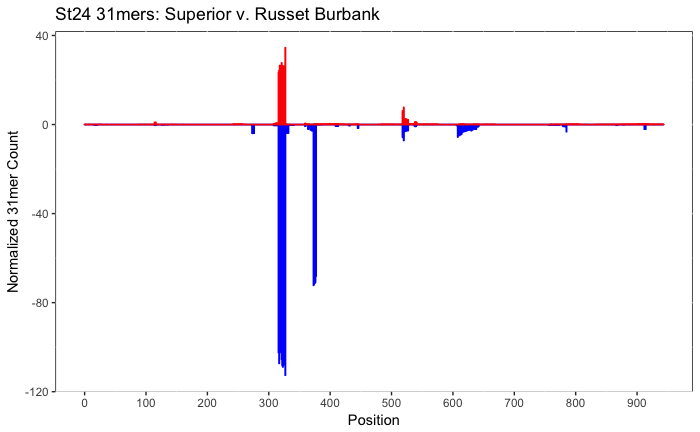

```r
ggplot(st24.counts.rb.indexed, aes(x = V3, y = V6)) +
  geom_bar(stat = "identity", color = "blue") +
  geom_bar(data = st24.counts.sup.indexed, aes(x = V3, y = V5), stat = "identity", color = "red") +
  scale_x_continuous(breaks = seq(0,1000, by=100)) +
  labs(x = "Position", y = "Normalized 31mer Count") +
  ggtitle("St24 31mers: Superior v. Russet Burbank") +
  theme(panel.background = element_rect(fill = "white", color = "black"))
```

Investigate DM1-3 31mer frequency spectrum

```r
DM.31mers <- read.csv("DM_31_counts.txt", header = F, sep = " ")
head(DM.31mers)
```

```r
ggplot(filter(DM.31mers, V1 >= 3), aes(x=V1,y=V2)) +
  geom_line(color = "purple") +
  scale_x_continuous(limits = c(0,150)) +
  labs(x = "31-mer count", y = "31-mer volume") +
  # geom_vline(xintercept = 8) +
  theme(panel.background = element_rect(fill = "white", color = "black"))
```

[output not shown]

> Evidently, much of the tetraploid genome is unique at k=31, but there are a few homozygous regions remaining. It would be worth trying a larger k to get a frequency distribution that resembles a homozygous genome.

Estimate DM1-3 genome size from 31mer frequency distribution. Peak is at 24. Valley between error and single copy is at 8

```r
sum(as.numeric(DM.mers[7:10000,1] * DM.mers[1:10001,2])) / 24 # size in bp
(sum(as.numeric(DM.mers[7:10000,1] * DM.mers[7:10000,2])) / 24) / 1e6 # size in Mb
(844e6 - 822.3918e6) / 844e6
```

[output not shown]

> The 31mer estimate is about 2.56% (~20Mb) shorter than the genome size reported by PGSC (2011). Is this considered close enough? Compare with the 17mer distribution described in PGSC (2011)

```r
DM.17mers <- read.csv("DM_17_counts.txt", header = F, sep = ' ')
head(DM.17mers)
tail(DM.17mers)
ggplot(filter(DM.17mers, V1 >= 3), aes(x = V1, y = V2)) +
  geom_line(color = "red") +
  scale_x_continuous(limits = c(0,150)) +
  theme(panel.background = element_rect(color = "black", fill = "white")) +
  geom_vline(xintercept = c(11,30,49))
```

[output not shown]

> Error k-mers stop at count 11. Single copy peak is at 30. Single copy fraction stops at 49 Estimate genome size as before

```r
sum(as.numeric(DM.17mers[11:10000,1] * DM.17mers[11:10000,2])) / 30
```

[output not shown]

> Way underestimating. Probably a limitation with Jellyfish, which uses abundance 10,000 as a catch-all. There are 231,000 k-mers in this set with higher copy number than 10,000 that are being undercounted. Moral of the story: I’m not convinced that Jellyfish can be used to accurately infer k-mer size.

After reading Chapman, Mascher et al (2015) the k-mer analysis might prove interesting after all. Their approach: derive a value of k that differentiates the subgenomes of hexaploid wheat, then use that value of k to identify k-1mers that correspond to SNP for use in POPSEQ analysis.